# Handout 1 SAS: Introduction to data

## Getting Started

Load the data set of 20,000 observations

```sas
filename cdc url 'http://www.openintro.org/stat/data/cdc.csv';

proc import datafile=cdc
            out=work.cdc
            dbms=csv
            replace;
            getnames=yes;
run;
```

```
SAS Connection established. Subprocess id is 18327
```

[output not shown]

[output cut: 32 more lines]

[output not shown]

View the names of the variables

```sas
proc contents data=work.cdc short;
run;
```

The SAS System

The CONTENTS Procedure

| Alphabetic List of Variables for WORK.CDC |
| --- |
| age exerany gender genhlth height hlthplan smoke100 weight wtdesire |

### Exercise 1

How many cases are there in this data set? How many variables? For each variable, identify its data type (for example, categorical, numeric).

There are 9 variables.

Data Source: US CDC website.

- genhlth: A categorical vector indicating general health, with categories excellent, very good, good, fair, and poor.
- exerany: A categorical vector, 1 if the respondent exercised in the past month and 0 otherwise.
- hlthplan: A categorical vector, 1 if the respondent has some form of health coverage and 0 otherwise.
- smoke100: A categorical vector, 1 if the respondent has smoked at least 100 cigarettes in their entire life and 0 otherwise.
- height: A numerical vector, respondent's height in inches.
- weight: A numerical vector, respondent's weight in pounds.
- wtdesire: A numerical vector, respondent's desired weight in pounds.
- age: A numerical vector, respondent's age in years.
- gender: A categorical vector, respondent's gender.

Look at the first 10 rows of our data

```sas
proc print data=work.cdc (obs=10);
run;
```

The SAS System

| Obs | genhlth | exerany | hlthplan | smoke100 | height | weight | wtdesire | age | gender |
| --- | --- | --- | --- | --- | --- | --- | --- | --- | --- |
| 1 | good | 0 | 1 | 0 | 70 | 175 | 175 | 77 | m |
| 2 | good | 0 | 1 | 1 | 64 | 125 | 115 | 33 | f |
| 3 | good | 1 | 1 | 1 | 60 | 105 | 105 | 49 | f |
| 4 | good | 1 | 1 | 0 | 66 | 132 | 124 | 42 | f |
| 5 | very good | 0 | 1 | 0 | 61 | 150 | 130 | 55 | f |
| 6 | very good | 1 | 1 | 0 | 64 | 114 | 114 | 55 | f |
| 7 | very good | 1 | 1 | 0 | 71 | 194 | 185 | 31 | m |
| 8 | very good | 0 | 1 | 0 | 67 | 170 | 160 | 45 | m |
| 9 | good | 0 | 1 | 1 | 65 | 150 | 130 | 27 | f |
| 10 | good | 1 | 1 | 0 | 70 | 180 | 170 | 44 | m |

## Summaries and Tables

Look at numerical summary, such as mean, variance, standard deviation, minimum, maximum, and extreme observations

Summary statistic for weight

```sas
proc univariate data=work.cdc;
   var weight;
run;
```

The SAS System

The UNIVARIATE Procedure

Variable: weight

| Moments |  |  |  |
| --- | --- | --- | --- |
| N | 20000 | Sum Weights | 20000 |
| Mean | 169.68295 | Sum Observations | 3393659 |
| Std Deviation | 40.08097 | Variance | 1606.48415 |
| Skewness | 0.95572799 | Kurtosis | 1.99615504 |
| Uncorrected SS | 607974147 | Corrected SS | 32128076.6 |
| Coeff Variation | 23.6210945 | Std Error Mean | 0.28341526 |

| Basic Statistical Measures Location | Basic Statistical Measures Location | Basic Statistical Measures Variability | Basic Statistical Measures Variability |
| --- | --- | --- | --- |
| Mean | 169.6830 | Std Deviation | 40.08097 |
| Median | 165.0000 | Variance | 1606 |
| Mode | 160.0000 | Range | 432.00000 |
|  |  | Interquartile Range | 50.00000 |

| Tests for Location: Mu0=0 Test | Tests for Location: Mu0=0 Statistic | Tests for Location: Mu0=0 Statistic | Tests for Location: Mu0=0 p Value | Tests for Location: Mu0=0 p Value |
| --- | --- | --- | --- | --- |
| Student's t | t | 598.7079 | Pr > \|t\| | <.0001 |
| Sign | M | 10000 | Pr >= \|M\| | <.0001 |
| Signed Rank | S | 1.0001E8 | Pr >= \|S\| | <.0001 |

| Quantiles (Definition 5) Level | Quantiles (Definition 5) Quantile |
| --- | --- |
| 100% Max | 500 |
| 99% | 290 |
| 95% | 240 |
| 90% | 220 |
| 75% Q3 | 190 |
| 50% Median | 165 |
| 25% Q1 | 140 |
| 10% | 124 |
| 5% | 115 |
| 1% | 100 |
| 0% Min | 68 |

| Extreme Observations Lowest Value | Extreme Observations Lowest Obs | Extreme Observations Highest Value | Extreme Observations Highest Obs |
| --- | --- | --- | --- |
| 68 | 18743 | 400 | 2944 |
| 70 | 16531 | 400 | 19319 |
| 78 | 18065 | 405 | 15720 |
| 78 | 11299 | 495 | 4445 |
| 79 | 7614 | 500 | 1995 |

The sample frequency distribution for smoke100

```sas
proc freq data=work.cdc;
    tables Smoke100;
run;
```

The SAS System

The FREQ Procedure

| smoke100 | Frequency | Percent | Cumulative Frequency | Cumulative Percent |
| --- | --- | --- | --- | --- |
| 0 | 10559 | 52.80 | 10559 | 52.80 |
| 1 | 9441 | 47.21 | 20000 | 100.00 |

Graph the sample frequency distribution for smoke100

The SAS System

The FREQ Procedure

| smoke100 | Frequency | Percent | Cumulative Frequency | Cumulative Percent |
| --- | --- | --- | --- | --- |
| 0 | 10559 | 52.80 | 10559 | 52.80 |
| 1 | 9441 | 47.21 | 20000 | 100.00 |

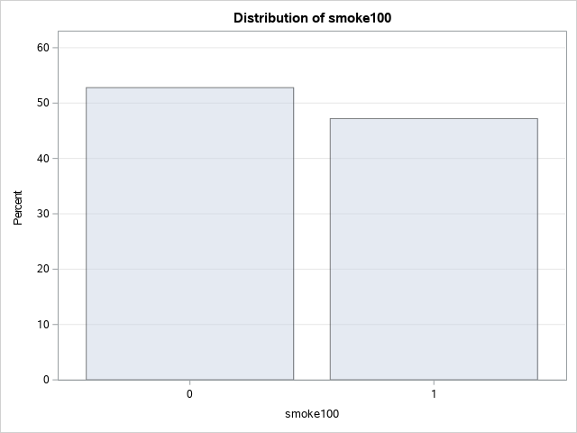

```sas
proc freq data=work.cdc;
    tables Smoke100 / plots=freqplot(scale=percent);
run;
```

### Exercise 2

Create a numerical summary for height and age, and compute the interquartile range for each. Compute the relative frequency distribution for gender and exerany. How many males are in the sample? What proportion of the sample reports being in excellent health?

There are 9569 males in the sample. A total of 4657 out out of 20000 reported being in excellent health. This is 23.29% of the sample.

Numerical summary for height and age

```sas
proc univariate data=work.cdc;
   var height;
   var age;
run;
```

The SAS System

The UNIVARIATE Procedure

Variable: height

| Moments |  |  |  |
| --- | --- | --- | --- |
| N | 20000 | Sum Weights | 20000 |
| Mean | 67.1829 | Sum Observations | 1343658 |
| Std Deviation | 4.12595429 | Variance | 17.0234988 |
| Skewness | 0.1036124 | Kurtosis | -0.3783851 |
| Uncorrected SS | 90611294 | Corrected SS | 340452.952 |
| Coeff Variation | 6.14137569 | Std Error Mean | 0.0291749 |

| Basic Statistical Measures Location | Basic Statistical Measures Location | Basic Statistical Measures Variability | Basic Statistical Measures Variability |
| --- | --- | --- | --- |
| Mean | 67.18290 | Std Deviation | 4.12595 |
| Median | 67.00000 | Variance | 17.02350 |
| Mode | 66.00000 | Range | 45.00000 |
|  |  | Interquartile Range | 6.00000 |

| Tests for Location: Mu0=0 Test | Tests for Location: Mu0=0 Statistic | Tests for Location: Mu0=0 Statistic | Tests for Location: Mu0=0 p Value | Tests for Location: Mu0=0 p Value |
| --- | --- | --- | --- | --- |
| Student's t | t | 2302.763 | Pr > \|t\| | <.0001 |
| Sign | M | 10000 | Pr >= \|M\| | <.0001 |
| Signed Rank | S | 1.0001E8 | Pr >= \|S\| | <.0001 |

| Quantiles (Definition 5) Level | Quantiles (Definition 5) Quantile |
| --- | --- |
| 100% Max | 93 |
| 99% | 76 |
| 95% | 74 |
| 90% | 73 |
| 75% Q3 | 70 |
| 50% Median | 67 |
| 25% Q1 | 64 |
| 10% | 62 |
| 5% | 61 |
| 1% | 59 |
| 0% Min | 48 |

| Extreme Observations Lowest Value | Extreme Observations Lowest Obs | Extreme Observations Highest Value | Extreme Observations Highest Obs |
| --- | --- | --- | --- |
| 48 | 15465 | 82 | 10160 |
| 48 | 5412 | 82 | 10322 |
| 49 | 8871 | 83 | 3691 |
| 50 | 3905 | 84 | 18817 |
| 51 | 11948 | 93 | 17534 |

The SAS System

The UNIVARIATE Procedure

Variable: age

| Moments |  |  |  |
| --- | --- | --- | --- |
| N | 20000 | Sum Weights | 20000 |
| Mean | 45.06825 | Sum Observations | 901365 |
| Std Deviation | 17.1926895 | Variance | 295.588571 |
| Skewness | 0.45170032 | Kurtosis | -0.6548259 |
| Uncorrected SS | 46534419 | Corrected SS | 5911475.84 |
| Coeff Variation | 38.1481186 | Std Error Mean | 0.12157067 |

| Basic Statistical Measures Location | Basic Statistical Measures Location | Basic Statistical Measures Variability | Basic Statistical Measures Variability |
| --- | --- | --- | --- |
| Mean | 45.06825 | Std Deviation | 17.19269 |
| Median | 43.00000 | Variance | 295.58857 |
| Mode | 40.00000 | Range | 81.00000 |
|  |  | Interquartile Range | 26.00000 |

| Tests for Location: Mu0=0 Test | Tests for Location: Mu0=0 Statistic | Tests for Location: Mu0=0 Statistic | Tests for Location: Mu0=0 p Value | Tests for Location: Mu0=0 p Value |
| --- | --- | --- | --- | --- |
| Student's t | t | 370.7165 | Pr > \|t\| | <.0001 |
| Sign | M | 10000 | Pr >= \|M\| | <.0001 |
| Signed Rank | S | 1.0001E8 | Pr >= \|S\| | <.0001 |

| Quantiles (Definition 5) Level | Quantiles (Definition 5) Quantile |
| --- | --- |
| 100% Max | 99 |
| 99% | 84 |
| 95% | 76 |
| 90% | 71 |
| 75% Q3 | 57 |
| 50% Median | 43 |
| 25% Q1 | 31 |
| 10% | 24 |
| 5% | 21 |
| 1% | 18 |
| 0% Min | 18 |

| Extreme Observations Lowest Value | Extreme Observations Lowest Obs | Extreme Observations Highest Value | Extreme Observations Highest Obs |
| --- | --- | --- | --- |
| 18 | 19885 | 95 | 16084 |
| 18 | 19860 | 96 | 17051 |
| 18 | 19832 | 97 | 10350 |
| 18 | 19706 | 99 | 900 |
| 18 | 19622 | 99 | 6710 |

Compute the interquartile range for height and age

Relative frequency distribution for gender

The SAS System

The FREQ Procedure

| gender | Frequency | Percent | Cumulative Frequency | Cumulative Percent |
| --- | --- | --- | --- | --- |
| f | 10431 | 52.16 | 10431 | 52.16 |
| m | 9569 | 47.85 | 20000 | 100.00 |

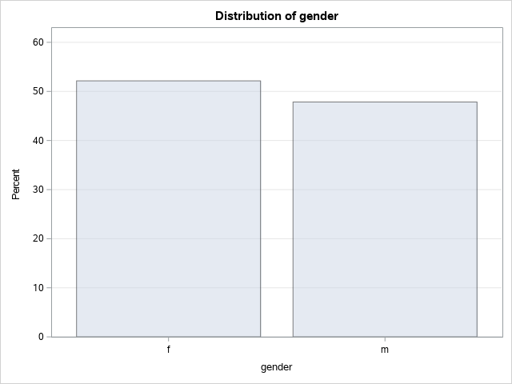

```sas
proc freq data=work.cdc;
    tables gender / plots=freqplot(scale=percent);
run;
```

Relative frequency distribution for exerany

The SAS System

The FREQ Procedure

| exerany | Frequency | Percent | Cumulative Frequency | Cumulative Percent |
| --- | --- | --- | --- | --- |
| 0 | 5086 | 25.43 | 5086 | 25.43 |
| 1 | 14914 | 74.57 | 20000 | 100.00 |

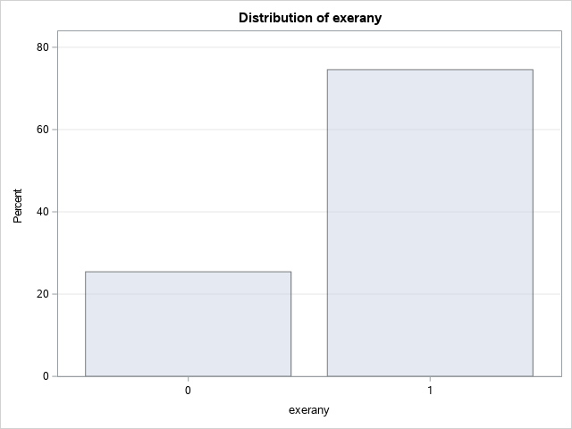

```sas
proc freq data=work.cdc;
    tables exerany / plots=freqplot(scale=percent);
run;
```

Relative frequency distribution for smoke100

The SAS System

The FREQ Procedure

| smoke100 | Frequency | Percent | Cumulative Frequency | Cumulative Percent |
| --- | --- | --- | --- | --- |
| 0 | 10559 | 52.80 | 10559 | 52.80 |
| 1 | 9441 | 47.21 | 20000 | 100.00 |

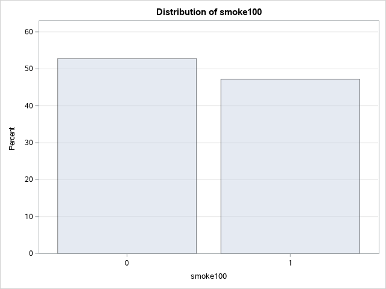

```sas
proc freq data=work.cdc;
    tables smoke100 / plots=freqplot(scale=percent);
run;
```

Relative frequency distribution for genhlth

The SAS System

The FREQ Procedure

| genhlth | Frequency | Percent | Cumulative Frequency | Cumulative Percent |
| --- | --- | --- | --- | --- |
| excellent | 4657 | 23.29 | 4657 | 23.29 |
| fair | 2019 | 10.10 | 6676 | 33.38 |
| good | 5675 | 28.38 | 12351 | 61.76 |
| poor | 677 | 3.39 | 13028 | 65.14 |
| very good | 6972 | 34.86 | 20000 | 100.00 |

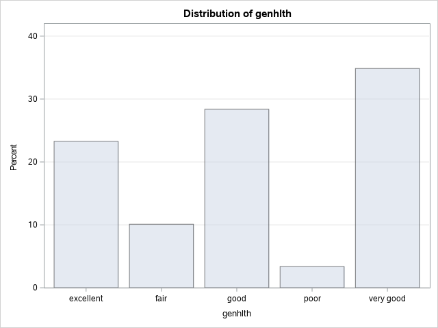

```sas
proc freq data=work.cdc;
    tables genhlth / plots=freqplot(scale=percent);
run;
```

Create multi-way frequency tables: gender and smoke100

```sas
proc freq data=work.cdc;
   tables gender*smoke100;
run;
```

The SAS System

The FREQ Procedure

| Frequency Percent Row Pct Col Pct |
| --- |

| Table of gender by smoke100 gender | Table of gender by smoke100 smoke100 0 | Table of gender by smoke100 smoke100 1 | Table of gender by smoke100 smoke100 Total |
| --- | --- | --- | --- |
| f | 6012 30.06 57.64 56.94 | 4419 22.10 42.36 46.81 | 10431 52.16 |
| m | 4547 22.74 47.52 43.06 | 5022 25.11 52.48 53.19 | 9569 47.85 |
| Total | 10559 52.80 | 9441 47.21 | 20000 100.00 |

Create a mosaic plot

The SAS System

The FREQ Procedure

| Frequency Percent Row Pct Col Pct |
| --- |

| Table of gender by smoke100 gender | Table of gender by smoke100 smoke100 0 | Table of gender by smoke100 smoke100 1 | Table of gender by smoke100 smoke100 Total |
| --- | --- | --- | --- |
| f | 6012 30.06 57.64 56.94 | 4419 22.10 42.36 46.81 | 10431 52.16 |
| m | 4547 22.74 47.52 43.06 | 5022 25.11 52.48 53.19 | 9569 47.85 |
| Total | 10559 52.80 | 9441 47.21 | 20000 100.00 |

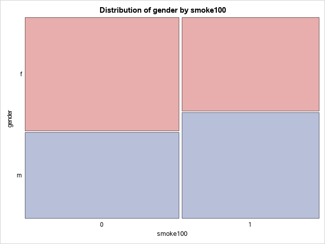

```sas
proc freq data=work.cdc;
    tables Gender*Smoke100 / plots=mosaicplot;
run;
```

### Exercise 3

What does the mosaic plot reveal about smoking habits and gender?

The percentage of males that smoked at least 100 cigarettes in their entire life is larger than percentage of females.

## Interlude: How SAS Processes Data

See the first 10 values in the data portion

```sas
proc print data=work.cdc (obs=10);
run;
```

The SAS System

| Obs | genhlth | exerany | hlthplan | smoke100 | height | weight | wtdesire | age | gender |
| --- | --- | --- | --- | --- | --- | --- | --- | --- | --- |
| 1 | good | 0 | 1 | 0 | 70 | 175 | 175 | 77 | m |
| 2 | good | 0 | 1 | 1 | 64 | 125 | 115 | 33 | f |
| 3 | good | 1 | 1 | 1 | 60 | 105 | 105 | 49 | f |
| 4 | good | 1 | 1 | 0 | 66 | 132 | 124 | 42 | f |
| 5 | very good | 0 | 1 | 0 | 61 | 150 | 130 | 55 | f |
| 6 | very good | 1 | 1 | 0 | 64 | 114 | 114 | 55 | f |
| 7 | very good | 1 | 1 | 0 | 71 | 194 | 185 | 31 | m |
| 8 | very good | 0 | 1 | 0 | 67 | 170 | 160 | 45 | m |
| 9 | good | 0 | 1 | 1 | 65 | 150 | 130 | 27 | f |
| 10 | good | 1 | 1 | 0 | 70 | 180 | 170 | 44 | m |

See the descriptor portion such as the names, types, and lengths of the variables

```sas
proc contents data=work.cdc;
run;
```

The SAS System

The CONTENTS Procedure

| Data Set Name | WORK.CDC | Observations | 20000 |
| --- | --- | --- | --- |
| Member Type | DATA | Variables | 9 |
| Engine | V9 | Indexes | 0 |
| Created | 07/07/2018 06:06:24 | Observation Length | 72 |
| Last Modified | 07/07/2018 06:06:24 | Deleted Observations | 0 |
| Protection |  | Compressed | NO |
| Data Set Type |  | Sorted | NO |
| Label |  |  |  |
| Data Representation | SOLARIS_X86_64, LINUX_X86_64, ALPHA_TRU64, LINUX_IA64 |  |  |
| Encoding | utf-8 Unicode (UTF-8) |  |  |

| Engine/Host Dependent Information |  |
| --- | --- |
| Data Set Page Size | 65536 |
| Number of Data Set Pages | 23 |
| First Data Page | 1 |
| Max Obs per Page | 908 |
| Obs in First Data Page | 867 |
| Number of Data Set Repairs | 0 |
| Filename | /tmp/SAS_work89DD00004797_localhost.localdomain/cdc.sas7bdat |
| Release Created | 9.0401M5 |
| Host Created | Linux |
| Inode Number | 409728 |
| Access Permission | rw-r--r-- |
| Owner Name | sasdemo |
| File Size | 2MB |
| File Size (bytes) | 1572864 |

| Alphabetic List of Variables and Attributes # | Alphabetic List of Variables and Attributes Variable | Alphabetic List of Variables and Attributes Type | Alphabetic List of Variables and Attributes Len | Alphabetic List of Variables and Attributes Format | Alphabetic List of Variables and Attributes Informat |
| --- | --- | --- | --- | --- | --- |
| 8 | age | Num | 8 | BEST12. | BEST32. |
| 2 | exerany | Num | 8 | BEST12. | BEST32. |
| 9 | gender | Char | 1 | $1. | $1. |
| 1 | genhlth | Char | 9 | $9. | $9. |
| 5 | height | Num | 8 | BEST12. | BEST32. |
| 3 | hlthplan | Num | 8 | BEST12. | BEST32. |
| 4 | smoke100 | Num | 8 | BEST12. | BEST32. |
| 6 | weight | Num | 8 | BEST12. | BEST32. |
| 7 | wtdesire | Num | 8 | BEST12. | BEST32. |

```sas
data work.newcdc;
   set work.cdc;
   if gender="m" and age>30;
run;

proc print data=work.newcdc (obs=10);
run;
```

The SAS System

| Obs | genhlth | exerany | hlthplan | smoke100 | height | weight | wtdesire | age | gender |
| --- | --- | --- | --- | --- | --- | --- | --- | --- | --- |
| 1 | good | 0 | 1 | 0 | 70 | 175 | 175 | 77 | m |
| 2 | very good | 1 | 1 | 0 | 71 | 194 | 185 | 31 | m |
| 3 | very good | 0 | 1 | 0 | 67 | 170 | 160 | 45 | m |
| 4 | good | 1 | 1 | 0 | 70 | 180 | 170 | 44 | m |
| 5 | excellent | 1 | 1 | 1 | 69 | 186 | 175 | 46 | m |
| 6 | fair | 1 | 1 | 1 | 69 | 168 | 148 | 62 | m |
| 7 | excellent | 1 | 1 | 1 | 70 | 170 | 170 | 69 | m |
| 8 | good | 1 | 1 | 1 | 73 | 185 | 175 | 79 | m |
| 9 | good | 0 | 0 | 1 | 67 | 156 | 150 | 47 | m |
| 10 | fair | 0 | 1 | 1 | 71 | 185 | 185 | 76 | m |

```sas
data work.newcdc;
   set work.cdc;
   if gender="m" or (gender="f" and age>30);
run;

proc print data=work.newcdc (obs=10);
run;
```

The SAS System

| Obs | genhlth | exerany | hlthplan | smoke100 | height | weight | wtdesire | age | gender |
| --- | --- | --- | --- | --- | --- | --- | --- | --- | --- |
| 1 | good | 0 | 1 | 0 | 70 | 175 | 175 | 77 | m |
| 2 | good | 0 | 1 | 1 | 64 | 125 | 115 | 33 | f |
| 3 | good | 1 | 1 | 1 | 60 | 105 | 105 | 49 | f |
| 4 | good | 1 | 1 | 0 | 66 | 132 | 124 | 42 | f |
| 5 | very good | 0 | 1 | 0 | 61 | 150 | 130 | 55 | f |
| 6 | very good | 1 | 1 | 0 | 64 | 114 | 114 | 55 | f |
| 7 | very good | 1 | 1 | 0 | 71 | 194 | 185 | 31 | m |
| 8 | very good | 0 | 1 | 0 | 67 | 170 | 160 | 45 | m |
| 9 | good | 1 | 1 | 0 | 70 | 180 | 170 | 44 | m |
| 10 | excellent | 1 | 1 | 1 | 69 | 186 | 175 | 46 | m |

### Exercise 4

Create a new data set named under23smoke that contains all observations of respondents under the age of 23 that have smoked 100 cigarettes in their lifetime. Write the programming statements you used to create the new data set as the answer to this exercise.

```sas
data work.under23smoke;
   set work.cdc;
   if smoke100=1 and age<23;
run;

proc print data=work.under23smoke (obs=10);
run;
```

The SAS System

| Obs | genhlth | exerany | hlthplan | smoke100 | height | weight | wtdesire | age | gender |
| --- | --- | --- | --- | --- | --- | --- | --- | --- | --- |
| 1 | excellent | 1 | 0 | 1 | 66 | 185 | 220 | 21 | m |
| 2 | very good | 1 | 0 | 1 | 70 | 160 | 140 | 18 | f |
| 3 | excellent | 1 | 1 | 1 | 74 | 175 | 200 | 22 | m |
| 4 | good | 1 | 1 | 1 | 64 | 190 | 140 | 20 | f |
| 5 | very good | 1 | 1 | 1 | 62 | 92 | 92 | 21 | f |
| 6 | very good | 1 | 0 | 1 | 64 | 125 | 115 | 22 | f |
| 7 | fair | 0 | 1 | 1 | 71 | 185 | 185 | 20 | m |
| 8 | fair | 1 | 1 | 1 | 72 | 185 | 170 | 19 | m |
| 9 | excellent | 1 | 0 | 1 | 63 | 105 | 100 | 19 | m |
| 10 | fair | 1 | 1 | 1 | 71 | 185 | 150 | 18 | m |

## Quantitative Data

Create box-and-whisker plot and a histogram for weight

The SAS System

The UNIVARIATE Procedure

Variable: weight

| Moments |  |  |  |
| --- | --- | --- | --- |
| N | 20000 | Sum Weights | 20000 |
| Mean | 169.68295 | Sum Observations | 3393659 |
| Std Deviation | 40.08097 | Variance | 1606.48415 |
| Skewness | 0.95572799 | Kurtosis | 1.99615504 |
| Uncorrected SS | 607974147 | Corrected SS | 32128076.6 |
| Coeff Variation | 23.6210945 | Std Error Mean | 0.28341526 |

| Basic Statistical Measures Location | Basic Statistical Measures Location | Basic Statistical Measures Variability | Basic Statistical Measures Variability |
| --- | --- | --- | --- |
| Mean | 169.6830 | Std Deviation | 40.08097 |
| Median | 165.0000 | Variance | 1606 |
| Mode | 160.0000 | Range | 432.00000 |
|  |  | Interquartile Range | 50.00000 |

| Tests for Location: Mu0=0 Test | Tests for Location: Mu0=0 Statistic | Tests for Location: Mu0=0 Statistic | Tests for Location: Mu0=0 p Value | Tests for Location: Mu0=0 p Value |
| --- | --- | --- | --- | --- |
| Student's t | t | 598.7079 | Pr > \|t\| | <.0001 |
| Sign | M | 10000 | Pr >= \|M\| | <.0001 |
| Signed Rank | S | 1.0001E8 | Pr >= \|S\| | <.0001 |

| Quantiles (Definition 5) Level | Quantiles (Definition 5) Quantile |
| --- | --- |
| 100% Max | 500 |
| 99% | 290 |
| 95% | 240 |
| 90% | 220 |
| 75% Q3 | 190 |
| 50% Median | 165 |
| 25% Q1 | 140 |
| 10% | 124 |
| 5% | 115 |
| 1% | 100 |
| 0% Min | 68 |

| Extreme Observations Lowest Value | Extreme Observations Lowest Obs | Extreme Observations Highest Value | Extreme Observations Highest Obs |
| --- | --- | --- | --- |
| 68 | 18743 | 400 | 2944 |
| 70 | 16531 | 400 | 19319 |
| 78 | 18065 | 405 | 15720 |
| 78 | 11299 | 495 | 4445 |
| 79 | 7614 | 500 | 1995 |

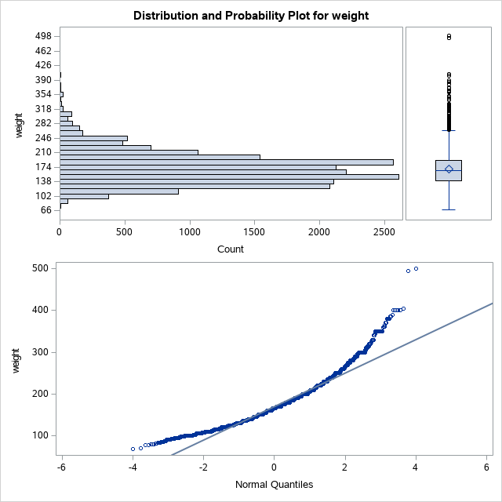

```sas
ods graphics;
proc univariate data=work.cdc plots;
    var weight;
run;
```

Create box-and-whisker plot and a histogram for weight subset by gender using "class" statement

The SAS System

The UNIVARIATE Procedure

Variable: weight

gender = f

| Moments |  |  |  |
| --- | --- | --- | --- |
| N | 10431 | Sum Weights | 10431 |
| Mean | 151.666187 | Sum Observations | 1582030 |
| Std Deviation | 34.2975191 | Variance | 1176.31981 |
| Skewness | 1.38530136 | Kurtosis | 3.77381659 |
| Uncorrected SS | 252209474 | Corrected SS | 12269015.7 |
| Coeff Variation | 22.6138203 | Std Error Mean | 0.33581472 |

| Basic Statistical Measures Location | Basic Statistical Measures Location | Basic Statistical Measures Variability | Basic Statistical Measures Variability |
| --- | --- | --- | --- |
| Mean | 151.6662 | Std Deviation | 34.29752 |
| Median | 145.0000 | Variance | 1176 |
| Mode | 140.0000 | Range | 427.00000 |
|  |  | Interquartile Range | 42.00000 |

| Tests for Location: Mu0=0 Test | Tests for Location: Mu0=0 Statistic | Tests for Location: Mu0=0 Statistic | Tests for Location: Mu0=0 p Value | Tests for Location: Mu0=0 p Value |
| --- | --- | --- | --- | --- |
| Student's t | t | 451.6365 | Pr > \|t\| | <.0001 |
| Sign | M | 5215.5 | Pr >= \|M\| | <.0001 |
| Signed Rank | S | 27204048 | Pr >= \|S\| | <.0001 |

| Quantiles (Definition 5) Level | Quantiles (Definition 5) Quantile |
| --- | --- |
| 100% Max | 495 |
| 99% | 260 |
| 95% | 220 |
| 90% | 198 |
| 75% Q3 | 170 |
| 50% Median | 145 |
| 25% Q1 | 128 |
| 10% | 115 |
| 5% | 110 |
| 1% | 100 |
| 0% Min | 68 |

| Extreme Observations Lowest Value | Extreme Observations Lowest Obs | Extreme Observations Highest Value | Extreme Observations Highest Obs |
| --- | --- | --- | --- |
| 68 | 18743 | 350 | 13607 |
| 70 | 16531 | 371 | 4612 |
| 78 | 11299 | 380 | 7160 |
| 79 | 7614 | 400 | 19319 |
| 80 | 15673 | 495 | 4445 |

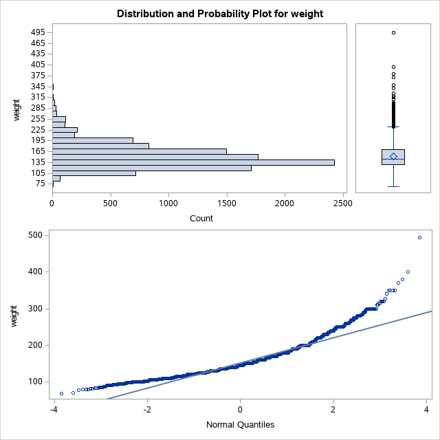

The SAS System

The UNIVARIATE Procedure

Variable: weight

gender = m

| Moments |  |  |  |
| --- | --- | --- | --- |
| N | 9569 | Sum Weights | 9569 |
| Mean | 189.322709 | Sum Observations | 1811629 |
| Std Deviation | 36.5503551 | Variance | 1335.92846 |
| Skewness | 1.16960127 | Kurtosis | 3.04520553 |
| Uncorrected SS | 355764673 | Corrected SS | 12782163.5 |
| Coeff Variation | 19.3058484 | Std Error Mean | 0.37364427 |

| Basic Statistical Measures Location | Basic Statistical Measures Location | Basic Statistical Measures Variability | Basic Statistical Measures Variability |
| --- | --- | --- | --- |
| Mean | 189.3227 | Std Deviation | 36.55036 |
| Median | 185.0000 | Variance | 1336 |
| Mode | 180.0000 | Range | 422.00000 |
|  |  | Interquartile Range | 45.00000 |

| Tests for Location: Mu0=0 Test | Tests for Location: Mu0=0 Statistic | Tests for Location: Mu0=0 Statistic | Tests for Location: Mu0=0 p Value | Tests for Location: Mu0=0 p Value |
| --- | --- | --- | --- | --- |
| Student's t | t | 506.6924 | Pr > \|t\| | <.0001 |
| Sign | M | 4784.5 | Pr >= \|M\| | <.0001 |
| Signed Rank | S | 22893833 | Pr >= \|S\| | <.0001 |

| Quantiles (Definition 5) Level | Quantiles (Definition 5) Quantile |
| --- | --- |
| 100% Max | 500 |
| 99% | 300 |
| 95% | 256 |
| 90% | 235 |
| 75% Q3 | 210 |
| 50% Median | 185 |
| 25% Q1 | 165 |
| 10% | 150 |
| 5% | 140 |
| 1% | 125 |
| 0% Min | 78 |

| Extreme Observations Lowest Value | Extreme Observations Lowest Obs | Extreme Observations Highest Value | Extreme Observations Highest Obs |
| --- | --- | --- | --- |
| 78 | 18065 | 400 | 1279 |
| 86 | 15967 | 400 | 2659 |
| 90 | 303 | 400 | 2944 |
| 93 | 9558 | 405 | 15720 |
| 94 | 11333 | 500 | 1995 |

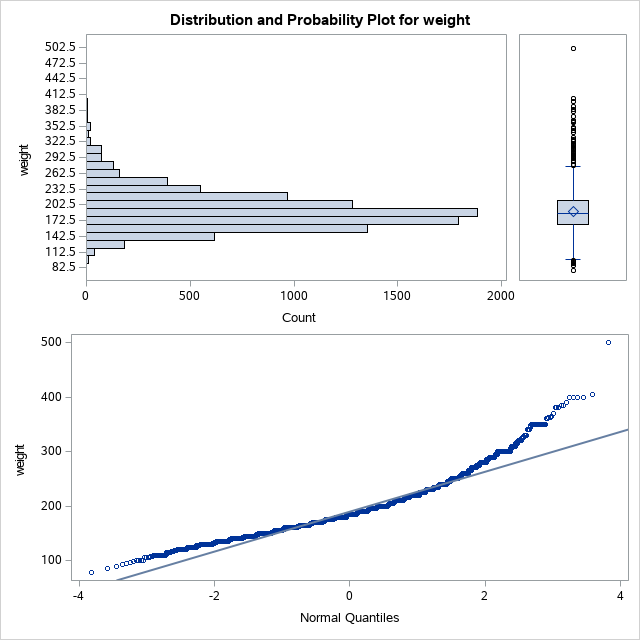

```sas
ods graphics;
proc univariate data=work.cdc plots;
    class gender;
    var weight;
run;
```

Create box-and-whisker plot and a histogram for weight subset by gender using "by" statement

The SAS System

The UNIVARIATE Procedure

Variable: weight

gender=f

| Moments |  |  |  |
| --- | --- | --- | --- |
| N | 10431 | Sum Weights | 10431 |
| Mean | 151.666187 | Sum Observations | 1582030 |
| Std Deviation | 34.2975191 | Variance | 1176.31981 |
| Skewness | 1.38530136 | Kurtosis | 3.77381659 |
| Uncorrected SS | 252209474 | Corrected SS | 12269015.7 |
| Coeff Variation | 22.6138203 | Std Error Mean | 0.33581472 |

| Basic Statistical Measures Location | Basic Statistical Measures Location | Basic Statistical Measures Variability | Basic Statistical Measures Variability |
| --- | --- | --- | --- |
| Mean | 151.6662 | Std Deviation | 34.29752 |
| Median | 145.0000 | Variance | 1176 |
| Mode | 140.0000 | Range | 427.00000 |
|  |  | Interquartile Range | 42.00000 |

| Tests for Location: Mu0=0 Test | Tests for Location: Mu0=0 Statistic | Tests for Location: Mu0=0 Statistic | Tests for Location: Mu0=0 p Value | Tests for Location: Mu0=0 p Value |
| --- | --- | --- | --- | --- |
| Student's t | t | 451.6365 | Pr > \|t\| | <.0001 |
| Sign | M | 5215.5 | Pr >= \|M\| | <.0001 |
| Signed Rank | S | 27204048 | Pr >= \|S\| | <.0001 |

| Quantiles (Definition 5) Level | Quantiles (Definition 5) Quantile |
| --- | --- |
| 100% Max | 495 |
| 99% | 260 |
| 95% | 220 |
| 90% | 198 |
| 75% Q3 | 170 |
| 50% Median | 145 |
| 25% Q1 | 128 |
| 10% | 115 |
| 5% | 110 |
| 1% | 100 |
| 0% Min | 68 |

| Extreme Observations Lowest Value | Extreme Observations Lowest Obs | Extreme Observations Highest Value | Extreme Observations Highest Obs |
| --- | --- | --- | --- |
| 68 | 9739 | 350 | 7051 |
| 70 | 8592 | 371 | 2354 |
| 78 | 5860 | 380 | 3663 |
| 79 | 3905 | 400 | 10060 |
| 80 | 8154 | 495 | 2284 |

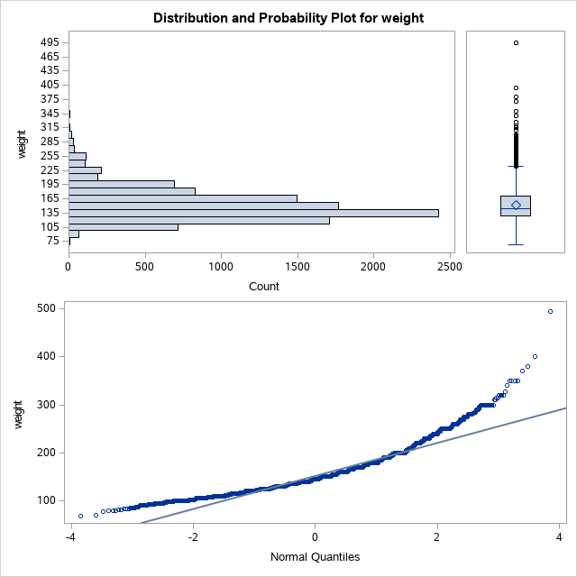

The SAS System

The UNIVARIATE Procedure

Variable: weight

gender=m

| Moments |  |  |  |
| --- | --- | --- | --- |
| N | 9569 | Sum Weights | 9569 |
| Mean | 189.322709 | Sum Observations | 1811629 |
| Std Deviation | 36.5503551 | Variance | 1335.92846 |
| Skewness | 1.16960127 | Kurtosis | 3.04520553 |
| Uncorrected SS | 355764673 | Corrected SS | 12782163.5 |
| Coeff Variation | 19.3058484 | Std Error Mean | 0.37364427 |

| Basic Statistical Measures Location | Basic Statistical Measures Location | Basic Statistical Measures Variability | Basic Statistical Measures Variability |
| --- | --- | --- | --- |
| Mean | 189.3227 | Std Deviation | 36.55036 |
| Median | 185.0000 | Variance | 1336 |
| Mode | 180.0000 | Range | 422.00000 |
|  |  | Interquartile Range | 45.00000 |

| Tests for Location: Mu0=0 Test | Tests for Location: Mu0=0 Statistic | Tests for Location: Mu0=0 Statistic | Tests for Location: Mu0=0 p Value | Tests for Location: Mu0=0 p Value |
| --- | --- | --- | --- | --- |
| Student's t | t | 506.6924 | Pr > \|t\| | <.0001 |
| Sign | M | 4784.5 | Pr >= \|M\| | <.0001 |
| Signed Rank | S | 22893833 | Pr >= \|S\| | <.0001 |

| Quantiles (Definition 5) Level | Quantiles (Definition 5) Quantile |
| --- | --- |
| 100% Max | 500 |
| 99% | 300 |
| 95% | 256 |
| 90% | 235 |
| 75% Q3 | 210 |
| 50% Median | 185 |
| 25% Q1 | 165 |
| 10% | 150 |
| 5% | 140 |
| 1% | 125 |
| 0% Min | 78 |

| Extreme Observations Lowest Value | Extreme Observations Lowest Obs | Extreme Observations Highest Value | Extreme Observations Highest Obs |
| --- | --- | --- | --- |
| 78 | 19127 | 400 | 11036 |
| 86 | 18099 | 400 | 11725 |
| 90 | 10578 | 400 | 11867 |
| 93 | 15074 | 405 | 17968 |
| 94 | 15887 | 500 | 11392 |

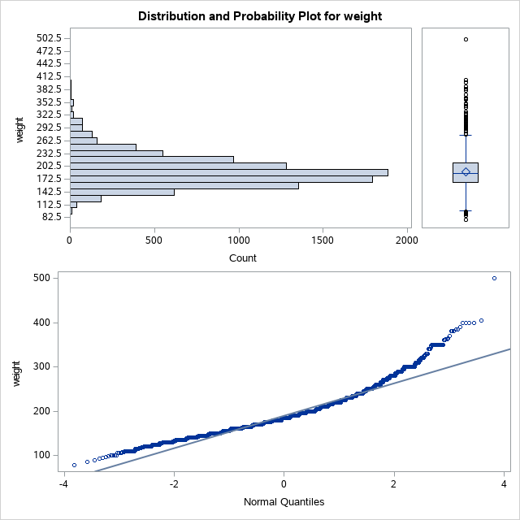

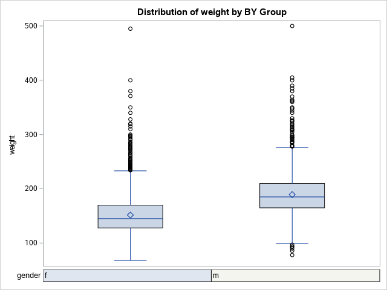

```sas
proc sort data=work.cdc;
    by gender;
run;

ods graphics;
proc univariate data=work.cdc plots;
    by gender;
    var Weight;
run;
```

Data set with a new variable named bmi

```sas
data work.cdcbmi;
    set work.cdc;
    bmi = (weight / height**2) * 703;
run;
```

[output not shown]

Alternative method to producing box-and-whisker plots using group statement

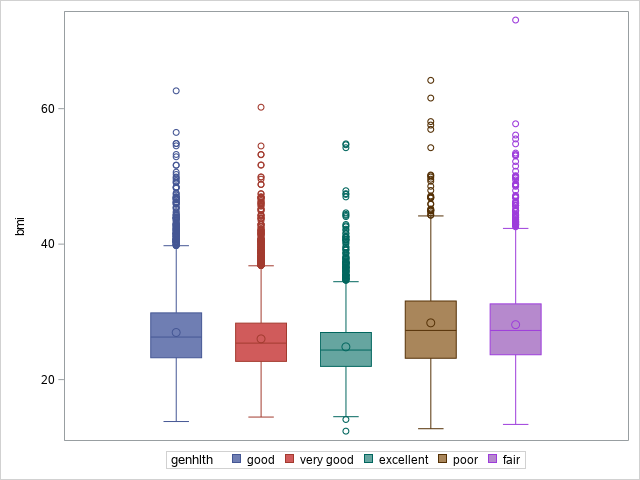

```sas
proc sgplot data=work.cdcbmi;
    vbox bmi / group=genhlth;
run;
```

### Exercise 5

What does this box plot show? Pick another categorical variable from the data set and see how it relates to BMI. List the variable you chose, why you might think it would have a relationship to BMI, and indicate what the figure seems to suggest.

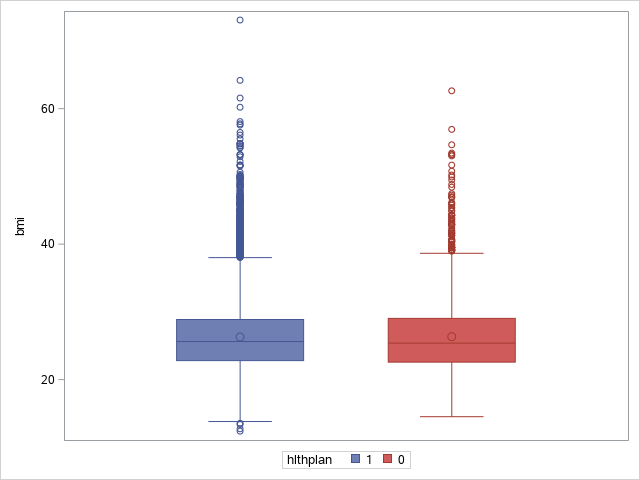

```sas
proc sgplot data=work.cdcbmi;
    vbox bmi / group=hlthplan;
run;
```

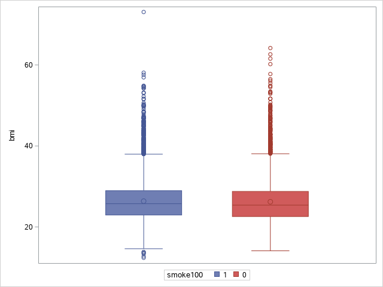

```sas
proc sgplot data=work.cdcbmi;
    vbox bmi / group=smoke100;
run;
```

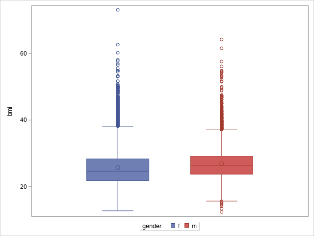

```sas
proc sgplot data=work.cdcbmi;
    vbox bmi / group=gender;
run;
```

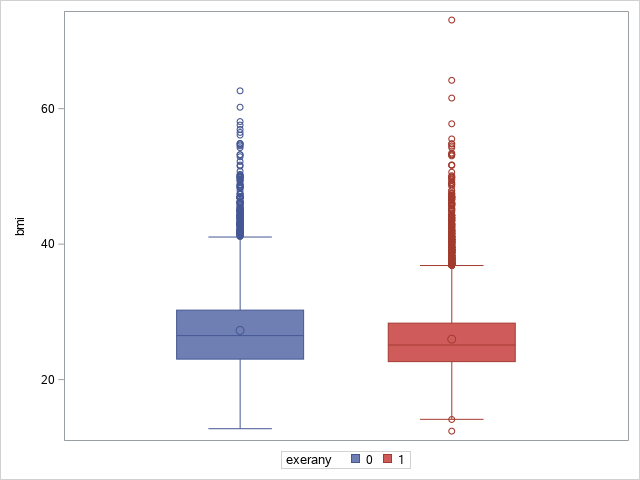

```sas
proc sgplot data=work.cdcbmi;
    vbox bmi / group=exerany;
run;
```

Histogram for the bmi of the respondents

The SAS System

The UNIVARIATE Procedure

Variable: bmi

| Moments |  |  |  |
| --- | --- | --- | --- |
| N | 20000 | Sum Weights | 20000 |
| Mean | 26.3069252 | Sum Observations | 526138.504 |
| Std Deviation | 5.21810488 | Variance | 27.2286186 |
| Skewness | 1.27589014 | Kurtosis | 3.32068097 |
| Uncorrected SS | 14385631.4 | Corrected SS | 544545.143 |
| Coeff Variation | 19.83548 | Std Error Mean | 0.03689757 |

| Basic Statistical Measures Location | Basic Statistical Measures Location | Basic Statistical Measures Variability | Basic Statistical Measures Variability |
| --- | --- | --- | --- |
| Mean | 26.30693 | Std Deviation | 5.21810 |
| Median | 25.60354 | Variance | 27.22862 |
| Mode | 27.12191 | Range | 60.69029 |
|  |  | Interquartile Range | 6.17852 |

| Tests for Location: Mu0=0 Test | Tests for Location: Mu0=0 Statistic | Tests for Location: Mu0=0 Statistic | Tests for Location: Mu0=0 p Value | Tests for Location: Mu0=0 p Value |
| --- | --- | --- | --- | --- |
| Student's t | t | 712.9717 | Pr > \|t\| | <.0001 |
| Sign | M | 10000 | Pr >= \|M\| | <.0001 |
| Signed Rank | S | 1.0001E8 | Pr >= \|S\| | <.0001 |

| Quantiles (Definition 5) Level | Quantiles (Definition 5) Quantile |
| --- | --- |
| 100% Max | 73.0907 |
| 99% | 43.5553 |
| 95% | 35.9509 |
| 90% | 32.8802 |
| 75% Q3 | 28.8862 |
| 50% Median | 25.6035 |
| 25% Q1 | 22.7077 |
| 10% | 20.5957 |
| 5% | 19.4835 |
| 1% | 17.7123 |
| 0% Min | 12.4005 |

| Extreme Observations Lowest Value | Extreme Observations Lowest Obs | Extreme Observations Highest Value | Extreme Observations Highest Obs |
| --- | --- | --- | --- |
| 12.4005 | 15887 | 60.2217 | 443 |
| 12.7495 | 3905 | 61.5733 | 17968 |
| 13.3872 | 19127 | 62.6420 | 10060 |
| 13.5565 | 8698 | 64.1892 | 11392 |
| 13.8104 | 2493 | 73.0907 | 2284 |

The SAS System

The UNIVARIATE Procedure

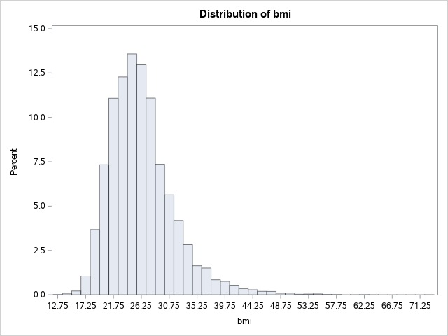

```sas
ods graphics;
proc univariate data=work.cdcbmi;
    var bmi;
    histogram bmi;
run;
```

Histogram for the bmi of the respondents grouped by gender

The SAS System

The UNIVARIATE Procedure

Variable: bmi

gender = f

| Moments |  |  |  |
| --- | --- | --- | --- |
| N | 10431 | Sum Weights | 10431 |
| Mean | 25.7411474 | Sum Observations | 268505.908 |
| Std Deviation | 5.62057729 | Variance | 31.5908891 |
| Skewness | 1.36746824 | Kurtosis | 3.1382735 |
| Uncorrected SS | 7241143.13 | Corrected SS | 329492.973 |
| Coeff Variation | 21.8349913 | Std Error Mean | 0.05503234 |

| Basic Statistical Measures Location | Basic Statistical Measures Location | Basic Statistical Measures Variability | Basic Statistical Measures Variability |
| --- | --- | --- | --- |
| Mean | 25.74115 | Std Deviation | 5.62058 |
| Median | 24.63832 | Variance | 31.59089 |
| Mode | 27.46094 | Range | 60.34120 |
|  |  | Interquartile Range | 6.55244 |

| Tests for Location: Mu0=0 Test | Tests for Location: Mu0=0 Statistic | Tests for Location: Mu0=0 Statistic | Tests for Location: Mu0=0 p Value | Tests for Location: Mu0=0 p Value |
| --- | --- | --- | --- | --- |
| Student's t | t | 467.7459 | Pr > \|t\| | <.0001 |
| Sign | M | 5215.5 | Pr >= \|M\| | <.0001 |
| Signed Rank | S | 27204048 | Pr >= \|S\| | <.0001 |

| Quantiles (Definition 5) Level | Quantiles (Definition 5) Quantile |
| --- | --- |
| 100% Max | 73.0907 |
| 99% | 44.3980 |
| 95% | 36.5765 |
| 90% | 32.9453 |
| 75% Q3 | 28.3396 |
| 50% Median | 24.6383 |
| 25% Q1 | 21.7872 |
| 10% | 19.8529 |
| 5% | 18.9853 |
| 1% | 17.2684 |
| 0% Min | 12.7495 |

| Extreme Observations Lowest Value | Extreme Observations Lowest Obs | Extreme Observations Highest Value | Extreme Observations Highest Obs |
| --- | --- | --- | --- |
| 12.7495 | 3905 | 57.7725 | 3663 |
| 13.5565 | 8698 | 58.1005 | 2354 |
| 13.8104 | 2493 | 60.2217 | 443 |
| 13.8156 | 5860 | 62.6420 | 10060 |
| 14.1367 | 8592 | 73.0907 | 2284 |

The SAS System

The UNIVARIATE Procedure

Variable: bmi

gender = m

| Moments |  |  |  |
| --- | --- | --- | --- |
| N | 9569 | Sum Weights | 9569 |
| Mean | 26.9236698 | Sum Observations | 257632.596 |
| Std Deviation | 4.6633462 | Variance | 21.7467978 |
| Skewness | 1.30603659 | Kurtosis | 3.92629137 |
| Uncorrected SS | 7144488.31 | Corrected SS | 208073.362 |
| Coeff Variation | 17.3206188 | Std Error Mean | 0.04767211 |

| Basic Statistical Measures Location | Basic Statistical Measures Location | Basic Statistical Measures Variability | Basic Statistical Measures Variability |
| --- | --- | --- | --- |
| Mean | 26.92367 | Std Deviation | 4.66335 |
| Median | 26.28313 | Variance | 21.74680 |
| Mode | 27.12191 | Range | 51.78874 |
|  |  | Interquartile Range | 5.41028 |

| Tests for Location: Mu0=0 Test | Tests for Location: Mu0=0 Statistic | Tests for Location: Mu0=0 Statistic | Tests for Location: Mu0=0 p Value | Tests for Location: Mu0=0 p Value |
| --- | --- | --- | --- | --- |
| Student's t | t | 564.7677 | Pr > \|t\| | <.0001 |
| Sign | M | 4784.5 | Pr >= \|M\| | <.0001 |
| Signed Rank | S | 22893833 | Pr >= \|S\| | <.0001 |

| Quantiles (Definition 5) Level | Quantiles (Definition 5) Quantile |
| --- | --- |
| 100% Max | 64.1892 |
| 99% | 42.0390 |
| 95% | 35.4379 |
| 90% | 32.5463 |
| 75% Q3 | 29.1561 |
| 50% Median | 26.2831 |
| 25% Q1 | 23.7458 |
| 10% | 21.9247 |
| 5% | 20.8031 |
| 1% | 18.6510 |
| 0% Min | 12.4005 |

| Extreme Observations Lowest Value | Extreme Observations Lowest Obs | Extreme Observations Highest Value | Extreme Observations Highest Obs |
| --- | --- | --- | --- |
| 12.4005 | 15887 | 54.8118 | 17510 |
| 13.3872 | 19127 | 56.1101 | 10796 |
| 14.1216 | 11534 | 57.5866 | 16778 |
| 14.5493 | 18866 | 61.5733 | 17968 |
| 14.7603 | 18099 | 64.1892 | 11392 |

The SAS System

The UNIVARIATE Procedure

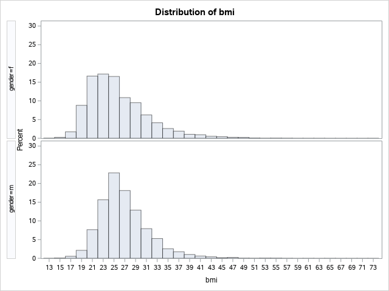

```sas
ods graphics;
proc univariate data=work.cdcbmi;
    class gender;
    var bmi;
    histogram bmi;
run;
```

The SAS System

The UNIVARIATE Procedure

Variable: bmi

| Moments |  |  |  |
| --- | --- | --- | --- |
| N | 20000 | Sum Weights | 20000 |
| Mean | 26.3069252 | Sum Observations | 526138.504 |
| Std Deviation | 5.21810488 | Variance | 27.2286186 |
| Skewness | 1.27589014 | Kurtosis | 3.32068097 |
| Uncorrected SS | 14385631.4 | Corrected SS | 544545.143 |
| Coeff Variation | 19.83548 | Std Error Mean | 0.03689757 |

| Basic Statistical Measures Location | Basic Statistical Measures Location | Basic Statistical Measures Variability | Basic Statistical Measures Variability |
| --- | --- | --- | --- |
| Mean | 26.30693 | Std Deviation | 5.21810 |
| Median | 25.60354 | Variance | 27.22862 |
| Mode | 27.12191 | Range | 60.69029 |
|  |  | Interquartile Range | 6.17852 |

| Tests for Location: Mu0=0 Test | Tests for Location: Mu0=0 Statistic | Tests for Location: Mu0=0 Statistic | Tests for Location: Mu0=0 p Value | Tests for Location: Mu0=0 p Value |
| --- | --- | --- | --- | --- |
| Student's t | t | 712.9717 | Pr > \|t\| | <.0001 |
| Sign | M | 10000 | Pr >= \|M\| | <.0001 |
| Signed Rank | S | 1.0001E8 | Pr >= \|S\| | <.0001 |

| Quantiles (Definition 5) Level | Quantiles (Definition 5) Quantile |
| --- | --- |
| 100% Max | 73.0907 |
| 99% | 43.5553 |
| 95% | 35.9509 |
| 90% | 32.8802 |
| 75% Q3 | 28.8862 |
| 50% Median | 25.6035 |
| 25% Q1 | 22.7077 |
| 10% | 20.5957 |
| 5% | 19.4835 |
| 1% | 17.7123 |
| 0% Min | 12.4005 |

| Extreme Observations Lowest Value | Extreme Observations Lowest Obs | Extreme Observations Highest Value | Extreme Observations Highest Obs |
| --- | --- | --- | --- |
| 12.4005 | 15887 | 60.2217 | 443 |
| 12.7495 | 3905 | 61.5733 | 17968 |
| 13.3872 | 19127 | 62.6420 | 10060 |
| 13.5565 | 8698 | 64.1892 | 11392 |
| 13.8104 | 2493 | 73.0907 | 2284 |

The SAS System

The UNIVARIATE Procedure

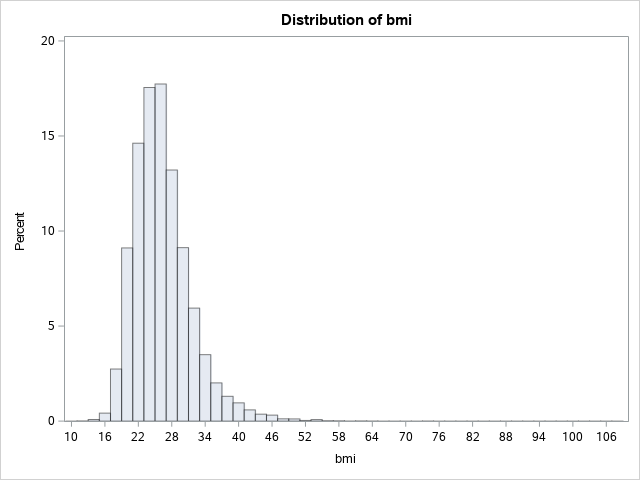

```sas
proc univariate data=work.cdcbmi;
   var bmi;
   histogram bmi / nmidpoints=50;
run;
```

The SAS System

The UNIVARIATE Procedure

Variable: bmi

| Moments |  |  |  |
| --- | --- | --- | --- |
| N | 20000 | Sum Weights | 20000 |
| Mean | 26.3069252 | Sum Observations | 526138.504 |
| Std Deviation | 5.21810488 | Variance | 27.2286186 |
| Skewness | 1.27589014 | Kurtosis | 3.32068097 |
| Uncorrected SS | 14385631.4 | Corrected SS | 544545.143 |
| Coeff Variation | 19.83548 | Std Error Mean | 0.03689757 |

| Basic Statistical Measures Location | Basic Statistical Measures Location | Basic Statistical Measures Variability | Basic Statistical Measures Variability |
| --- | --- | --- | --- |
| Mean | 26.30693 | Std Deviation | 5.21810 |
| Median | 25.60354 | Variance | 27.22862 |
| Mode | 27.12191 | Range | 60.69029 |
|  |  | Interquartile Range | 6.17852 |

| Tests for Location: Mu0=0 Test | Tests for Location: Mu0=0 Statistic | Tests for Location: Mu0=0 Statistic | Tests for Location: Mu0=0 p Value | Tests for Location: Mu0=0 p Value |
| --- | --- | --- | --- | --- |
| Student's t | t | 712.9717 | Pr > \|t\| | <.0001 |
| Sign | M | 10000 | Pr >= \|M\| | <.0001 |
| Signed Rank | S | 1.0001E8 | Pr >= \|S\| | <.0001 |

| Quantiles (Definition 5) Level | Quantiles (Definition 5) Quantile |
| --- | --- |
| 100% Max | 73.0907 |
| 99% | 43.5553 |
| 95% | 35.9509 |
| 90% | 32.8802 |
| 75% Q3 | 28.8862 |
| 50% Median | 25.6035 |
| 25% Q1 | 22.7077 |
| 10% | 20.5957 |
| 5% | 19.4835 |
| 1% | 17.7123 |
| 0% Min | 12.4005 |

| Extreme Observations Lowest Value | Extreme Observations Lowest Obs | Extreme Observations Highest Value | Extreme Observations Highest Obs |
| --- | --- | --- | --- |
| 12.4005 | 15887 | 60.2217 | 443 |
| 12.7495 | 3905 | 61.5733 | 17968 |
| 13.3872 | 19127 | 62.6420 | 10060 |
| 13.5565 | 8698 | 64.1892 | 11392 |
| 13.8104 | 2493 | 73.0907 | 2284 |

The SAS System

The UNIVARIATE Procedure

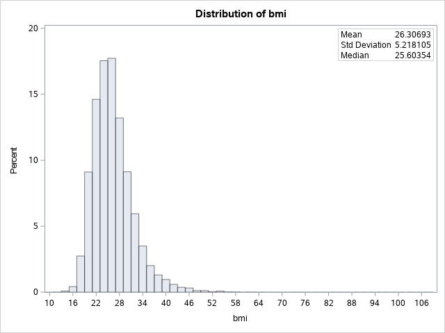

```sas
ods graphics;
proc univariate data=work.cdcbmi;
    var bmi;
    histogram bmi / nmidpoints=50;
    inset mean std median / position=NE;
run;
```